# **NLP Sentiment Analysis Platform**

## **Project Objective**

Social media platforms generate millions of opinions every day. The goal of this project is to analyze Twitter text data and predict whether a tweet expresses positive or negative sentiment using Natural Language Processing and Machine Learning.

## **Dataset**

This project uses the Sentiment140 Twitter dataset containing 1.6 million tweets with sentiment labels.

## **Target Variable**

`sentiment` → 4 = Positive Tweet, 0 = Negative Tweet

## **Project Workflow**

1. Import Libraries
2. Load Dataset
3. Data Understanding
4. Data Cleaning
5. Text Preprocessing
6. NLP Feature Engineering
7. Exploratory Data Analysis
8. Word Frequency Analysis
9. WordCloud Analysis
10. N-Gram Analysis
11. TF-IDF Vectorization
12. Model Building
13. Model Evaluation
14. Important Word Analysis
15. Custom Prediction System
16. Final Business Insights

# **Import Libraries**

```python
import pandas as pd
import numpy as np
import matplotlib.pyplot as plt
import seaborn as sns

import re
import string
from collections import Counter

import nltk
from nltk.corpus import stopwords
from nltk.stem import WordNetLemmatizer

from wordcloud import WordCloud

from sklearn.feature_extraction.text import CountVectorizer
from sklearn.model_selection import train_test_split
from sklearn.feature_extraction.text import TfidfVectorizer
from sklearn.naive_bayes import MultinomialNB
from sklearn.linear_model import LogisticRegression
from sklearn.svm import LinearSVC

from sklearn.metrics import accuracy_score, precision_score, recall_score, f1_score
from sklearn.metrics import classification_report, confusion_matrix
from sklearn.metrics import roc_auc_score

import joblib

import warnings
warnings.filterwarnings("ignore")
```

```python
nltk.download("stopwords")
nltk.download("wordnet")
nltk.download("omw-1.4")
```

```
True
```

*This step imports all required libraries for data analysis, visualization, NLP preprocessing, machine learning model building, evaluation, and model saving.*

# **Load Dataset**

```python
columns = ["sentiment","id","date","query","user","text"]
df = pd.read_csv("training.1600000.processed.noemoticon.csv",
    encoding="latin-1",
    header=None,
    names=columns
)
```

```python
df.head()
```

|  | sentiment | id | date | query | user | text |
| --- | --- | --- | --- | --- | --- | --- |
| 0 | 0 | 1467810369 | Mon Apr 06 22:19:45 PDT 2009 | NO_QUERY | _TheSpecialOne_ | @switchfoot http://twitpic.com/2y1zl - Awww, t... |
| 1 | 0 | 1467810672 | Mon Apr 06 22:19:49 PDT 2009 | NO_QUERY | scotthamilton | is upset that he can't update his Facebook by ... |
| 2 | 0 | 1467810917 | Mon Apr 06 22:19:53 PDT 2009 | NO_QUERY | mattycus | @Kenichan I dived many times for the ball. Man... |
| 3 | 0 | 1467811184 | Mon Apr 06 22:19:57 PDT 2009 | NO_QUERY | ElleCTF | my whole body feels itchy and like its on fire |
| 4 | 0 | 1467811193 | Mon Apr 06 22:19:57 PDT 2009 | NO_QUERY | Karoli | @nationwideclass no, it's not behaving at all.... |

```python
df.tail()
```

|  | sentiment | id | date | query | user | text |
| --- | --- | --- | --- | --- | --- | --- |
| 1599995 | 4 | 2193601966 | Tue Jun 16 08:40:49 PDT 2009 | NO_QUERY | AmandaMarie1028 | Just woke up. Having no school is the best fee... |
| 1599996 | 4 | 2193601969 | Tue Jun 16 08:40:49 PDT 2009 | NO_QUERY | TheWDBoards | TheWDB.com - Very cool to hear old Walt interv... |
| 1599997 | 4 | 2193601991 | Tue Jun 16 08:40:49 PDT 2009 | NO_QUERY | bpbabe | Are you ready for your MoJo Makeover? Ask me f... |
| 1599998 | 4 | 2193602064 | Tue Jun 16 08:40:49 PDT 2009 | NO_QUERY | tinydiamondz | Happy 38th Birthday to my boo of alll time!!! ... |
| 1599999 | 4 | 2193602129 | Tue Jun 16 08:40:50 PDT 2009 | NO_QUERY | RyanTrevMorris | happy #charitytuesday @theNSPCC @SparksCharity... |

```python
df.shape
```

```
(1600000, 6)
```

```python
df.columns
```

```
Index(['sentiment', 'id', 'date', 'query', 'user', 'text'], dtype='str')
```

```python
df.info()
```

```
<class 'pandas.DataFrame'>
RangeIndex: 1600000 entries, 0 to 1599999
Data columns (total 6 columns):
 #   Column     Non-Null Count    Dtype
---  ------     --------------    -----
 0   sentiment  1600000 non-null  int64
 1   id         1600000 non-null  int64
 2   date       1600000 non-null  str
 3   query      1600000 non-null  str
 4   user       1600000 non-null  str
 5   text       1600000 non-null  str
dtypes: int64(2), str(4)
memory usage: 256.9 MB
```

# **Data Cleaning**

```python
# Missing Values

missing_values = df.isnull().sum()

missing_percent = (df.isnull().sum() / len(df)) * 100

missing_df = pd.DataFrame({
    "Missing Values": missing_values,
    "Missing Percentage": missing_percent
})

missing_df
```

|  | Missing Values | Missing Percentage |
| --- | --- | --- |
| sentiment | 0 | 0.0 |
| id | 0 | 0.0 |
| date | 0 | 0.0 |
| query | 0 | 0.0 |
| user | 0 | 0.0 |
| text | 0 | 0.0 |

```python
# Duplicate Rows

duplicate_count = df.duplicated().sum()
print("Duplicate Rows:", duplicate_count)
```

```
Duplicate Rows: 0
```

```python
df["text"].dtype
```

```
<StringDtype(na_value=nan)>
```

```python
df["text"] = df["text"].astype(str)
```

```python
df["text"].dtype
```

```
<StringDtype(na_value=nan)>
```

# **Target Distribution**

```python
df["sentiment"] = df["sentiment"].replace({
    0: "Negative",
    4: "Positive"
})
```

```python
df["sentiment"].value_counts()
```

```
sentiment
Negative    800000
Positive    800000
Name: count, dtype: int64
```

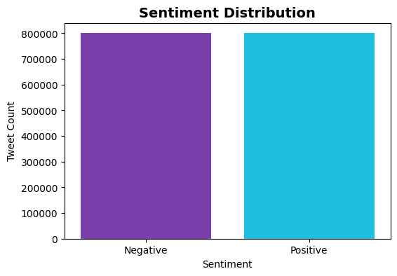

```python
# Sentiment Distribution

plt.figure(figsize=(6,4))
sns.countplot(data=df, x="sentiment", palette=["#7B2CBF", "#00D4FF"])
plt.title("Sentiment Distribution", fontsize=14, fontweight="bold")
plt.xlabel("Sentiment")
plt.ylabel("Tweet Count")
plt.show()
```

*The dataset contains 1.6M tweets.*

Negative has 800K, Positive has 800K.This indicates a perfectly balanced , containing an equal number of positive and negative tweets.

```python
df["sentiment"].value_counts(normalize=True) * 100
```

```
sentiment
Negative    50.0
Positive    50.0
Name: proportion, dtype: float64
```

# **Text Preprocessing Function**

```python
stop_words = set(stopwords.words("english"))
lemmatizer = WordNetLemmatizer()

def clean_text(text):
    text = text.lower()

    text = re.sub(r"&amp;|&lt;|&gt;", " ", text)

    text = re.sub(r"http\S+|www\S+|https\S+", "", text)

    text = re.sub(r"@\w+", "", text)

    text = re.sub(r"#", "", text)

    text = re.sub(r"\d+", "", text)

    text = re.sub(r"[^a-zA-Z\s]", "", text)

    text = re.sub(r"\s+", " ", text).strip()

    words = text.split()
    words = [
        lemmatizer.lemmatize(word)
        for word in words
        if word not in stop_words and len(word) > 2
    ]

    return " ".join(words)
```

```python
df["clean_text"] = df["text"].apply(clean_text)
```

```python
df[["text", "clean_text"]].head()
```

|  | text | clean_text |
| --- | --- | --- |
| 0 | @switchfoot http://twitpic.com/2y1zl - Awww, t... | thats bummer shoulda got david carr third day |
| 1 | is upset that he can't update his Facebook by ... | upset cant update facebook texting might cry r... |
| 2 | @Kenichan I dived many times for the ball. Man... | dived many time ball managed save rest bound |
| 3 | my whole body feels itchy and like its on fire | whole body feel itchy like fire |
| 4 | @nationwideclass no, it's not behaving at all.... | behaving mad cant see |

*Raw tweets contain URLs, mentions, hashtags, punctuation, numbers, and unnecessary stopwords. Text preprocessing removes noise and converts tweets into a cleaner format suitable for machine learning.*

```python
df[df["clean_text"] == ""].shape
```

[output not shown]

```python
df = df[df["clean_text"] != ""]
df.shape
```

[output not shown]

# **NLP Feature**

```python
df["original_text_length"] = df["text"].apply(len)
```

```python
df["original_text_length"].head(10)
```

```
0    115
1    111
2     89
3     47
4    111
5     29
6     11
7     99
8     36
9     25
Name: original_text_length, dtype: int64
```

```python
df["clean_text_length"] = df["clean_text"].apply(len)
```

```python
df["clean_text_length"].head(10)
```

```
0    45
1    74
2    44
3    31
4    21
5    10
6     8
7    55
8    10
9     9
Name: clean_text_length, dtype: int64
```

```python
df["original_word_count"] = df["text"].apply(lambda x: len(x.split()))
df["clean_word_count"] = df["clean_text"].apply(lambda x: len(x.split()))

df.head()
```

|  | sentiment | id | date | query | user | text | clean_text | original_text_length | clean_text_length | original_word_count | clean_word_count |
| --- | --- | --- | --- | --- | --- | --- | --- | --- | --- | --- | --- |
| 0 | Negative | 1467810369 | Mon Apr 06 22:19:45 PDT 2009 | NO_QUERY | _TheSpecialOne_ | @switchfoot http://twitpic.com/2y1zl - Awww, t... | thats bummer shoulda got david carr third day | 115 | 45 | 19 | 8 |
| 1 | Negative | 1467810672 | Mon Apr 06 22:19:49 PDT 2009 | NO_QUERY | scotthamilton | is upset that he can't update his Facebook by ... | upset cant update facebook texting might cry r... | 111 | 74 | 21 | 12 |
| 2 | Negative | 1467810917 | Mon Apr 06 22:19:53 PDT 2009 | NO_QUERY | mattycus | @Kenichan I dived many times for the ball. Man... | dived many time ball managed save rest bound | 89 | 44 | 18 | 8 |
| 3 | Negative | 1467811184 | Mon Apr 06 22:19:57 PDT 2009 | NO_QUERY | ElleCTF | my whole body feels itchy and like its on fire | whole body feel itchy like fire | 47 | 31 | 10 | 6 |
| 4 | Negative | 1467811193 | Mon Apr 06 22:19:57 PDT 2009 | NO_QUERY | Karoli | @nationwideclass no, it's not behaving at all.... | behaving mad cant see | 111 | 21 | 21 | 4 |

# **Text Length Analysis**

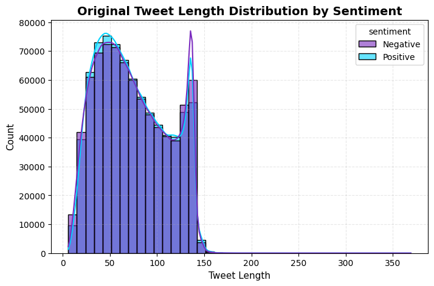

```python
plt.figure(figsize=(8,5))

sns.histplot(data=df,x="original_text_length",hue="sentiment",bins=40,
    kde=True,palette=["#7B2CBF", "#00D4FF"],alpha=0.6)

plt.title("Original Tweet Length Distribution by Sentiment",fontsize=14,fontweight="bold")

plt.xlabel("Tweet Length", fontsize=11)
plt.ylabel("Count", fontsize=11)

plt.grid(
    linestyle="--",
    alpha=0.3
)

plt.show()
```

*Most tweets are short — between 40 to 140 characters. There is a visible spike at exactly 140 characters,because that was Twitter's old character limit.*

Both Positive and Negative tweets followthe same length pattern — meaning a tweet'slength does not tell us whether it is positive or negative.

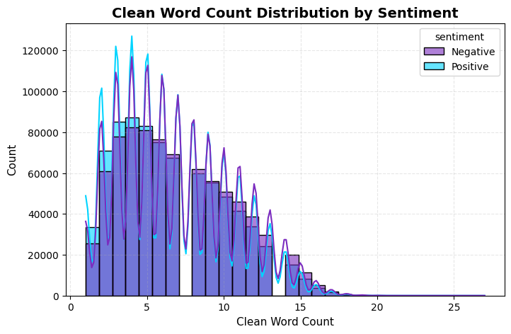

```python
plt.figure(figsize=(8,5))

sns.histplot(data=df,x="clean_word_count",hue="sentiment",bins=30,kde=True,
    palette=["#7B2CBF", "#00D4FF"],alpha=0.6)

plt.title("Clean Word Count Distribution by Sentiment",fontsize=14,fontweight="bold")

plt.xlabel("Clean Word Count", fontsize=11)
plt.ylabel("Count", fontsize=11)

plt.grid(
    linestyle="--",
    alpha=0.3
)

plt.show()
```

*After cleaning, most tweets contain between 3 to 8 meaningful words.*

Very few tweets have more than 15 words —which makes sense, as Twitter is a short-message platform.

Both Positive and Negative tweets show almost the same word count pattern — meaning word count alone cannot tell us whether a tweet is positive or negative.

```python
# Create Positive and Negative Text

positive_text = " ".join(df[df["sentiment"] == "Positive"]["clean_text"])
negative_text = " ".join(df[df["sentiment"] == "Negative"]["clean_text"])
```

```python
# Word Frequency Analysis
```

```python
print(positive_text[:500])
```

```
love guy best meeting one besties tonight cant wait girl talk thanks twitter add sunisa got meet hin show area sweetheart sick really cheap hurt much eat real food plus friend make soup effect everyone tell burst laughing really loud thanks making come sulk thans response ihad already find answer je…
```

```python
print(negative_text[:500])
```

```
thats bummer shoulda got david carr third day upset cant update facebook texting might cry result school today also blah dived many time ball managed save rest bound whole body feel itchy like fire behaving mad cant see whole crew need hug hey long time see yes rain bit bit lol fine thanks hows nope…
```

```python
# Positive words

positive_words = positive_text.split()
positive_word_freq = Counter(positive_words)

positive_common_words = pd.DataFrame(
    positive_word_freq.most_common(30),
    columns=["word", "count"]
)

positive_common_words
```

|  | word | count |
| --- | --- | --- |
| 0 | good | 60945 |
| 1 | day | 54008 |
| 2 | love | 49549 |
| 3 | get | 38105 |
| 4 | like | 37949 |
| 5 | thanks | 33846 |
| 6 | lol | 33532 |
| 7 | time | 33207 |
| 8 | going | 30655 |
| 9 | today | 29235 |
| 10 | got | 27801 |
| 11 | one | 27574 |
| 12 | new | 26652 |
| 13 | know | 26401 |
| 14 | see | 25590 |
| 15 | great | 24896 |
| 16 | well | 24609 |
| 17 | back | 23535 |
| 18 | night | 23169 |
| 19 | dont | 22152 |
| 20 | work | 20929 |
| 21 | haha | 20799 |
| 22 | think | 20521 |
| 23 | morning | 20270 |
| 24 | happy | 20139 |
| 25 | twitter | 19345 |
| 26 | cant | 19131 |
| 27 | hope | 19003 |
| 28 | really | 18335 |
| 29 | fun | 18089 |

```python
# Negative words:

negative_words = negative_text.split()
negative_word_freq = Counter(negative_words)

negative_common_words = pd.DataFrame(
    negative_word_freq.most_common(30),
    columns=["word", "count"]
)

negative_common_words
```

|  | word | count |
| --- | --- | --- |
| 0 | day | 50085 |
| 1 | get | 47844 |
| 2 | work | 45580 |
| 3 | dont | 45163 |
| 4 | cant | 43777 |
| 5 | like | 41155 |
| 6 | today | 36911 |
| 7 | want | 34038 |
| 8 | going | 33452 |
| 9 | got | 33104 |
| 10 | back | 32597 |
| 11 | miss | 31743 |
| 12 | really | 31231 |
| 13 | time | 30611 |
| 14 | still | 28785 |
| 15 | good | 28605 |
| 16 | one | 28323 |
| 17 | sad | 27173 |
| 18 | know | 26831 |
| 19 | feel | 25241 |
| 20 | need | 25195 |
| 21 | home | 23906 |
| 22 | wish | 23400 |
| 23 | think | 22983 |
| 24 | last | 22241 |
| 25 | lol | 21730 |
| 26 | bad | 21375 |
| 27 | see | 20476 |
| 28 | night | 20419 |
| 29 | sorry | 20324 |

[figure not shown]

```python
# Top 20 Words in Positive Tweets

plt.figure(figsize=(10,6))

sns.barplot(data=positive_common_words,x="count",y="word",palette="blend:#00D4FF,#7B2CBF")

plt.title("Top 20 Words in Positive Tweets",fontsize=15,fontweight="bold")

plt.xlabel("Frequency",fontsize=11)

plt.ylabel("Words",fontsize=11)

plt.grid(
    linestyle="--",
    alpha=0.3,
    axis="x"
)

sns.despine()

plt.show()
```

[figure not shown]

```python
# Negative chart

plt.figure(figsize=(10,6))

plt.hlines(y=negative_common_words["word"],xmin=0,xmax=negative_common_words["count"],
    color="#7B2CBF",alpha=0.8,linewidth=3)

plt.scatter(negative_common_words["count"],negative_common_words["word"],s=140,color="#00D4FF",
    edgecolor="#7B2CBF",linewidth=1.5,alpha=0.9)

plt.title("Top 20 Words in Negative Tweets",fontsize=15,fontweight="bold")

plt.xlabel("Frequency",fontsize=11)

plt.ylabel("Words",fontsize=11)

plt.grid(
    linestyle="--",
    alpha=0.3,
    axis="x"
)

sns.despine()
plt.gca().invert_yaxis()
plt.show()
```

# **WordCloud Analysis**

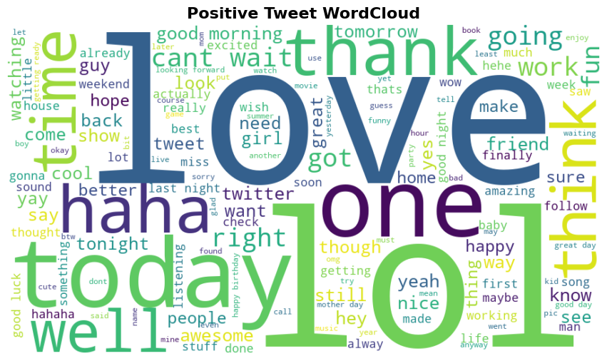

```python
# Positive word cloud

positive_wc = WordCloud(
    width=900,
    height=500,
    background_color="white",
    max_words=150
).generate(positive_text)

plt.figure(figsize=(12,6))
plt.imshow(positive_wc, interpolation="bilinear")
plt.axis("off")
plt.title("Positive Tweet WordCloud", fontsize=16, fontweight="bold")
plt.show()
```

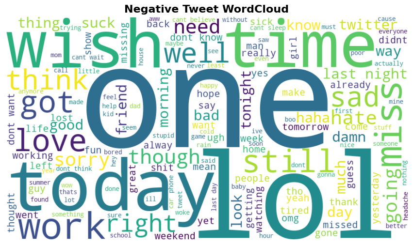

```python
# Negative word cloud

negative_wc = WordCloud(
    width=900,
    height=500,
    background_color="white",
    max_words=150
).generate(negative_text)

plt.figure(figsize=(12,6))
plt.imshow(negative_wc, interpolation="bilinear")
plt.axis("off")
plt.title("Negative Tweet WordCloud", fontsize=16, fontweight="bold")
plt.show()
```

*WordCloud visualizes use for the most frequent words in positive and negative tweets, making sentiment patterns easier to understand.*

# **N-Gram Analysis**

```python
# Bigram function

def get_top_ngrams(text_data, ngram_range=(2,2), top_n=20):
    vectorizer = CountVectorizer(ngram_range=ngram_range, stop_words="english")
    ngram_matrix = vectorizer.fit_transform(text_data)

    ngram_counts = np.asarray(ngram_matrix.sum(axis=0)).flatten()
    ngram_features = vectorizer.get_feature_names_out()

    ngram_df = pd.DataFrame({
        "ngram": ngram_features,
        "count": ngram_counts
    })

    return ngram_df.sort_values(by="count", ascending=False).head(top_n)
```

```python
# Positive bigrams

positive_bigrams = get_top_ngrams(
    df[df["sentiment"] == "Positive"]["clean_text"],
    ngram_range=(2,2),
    top_n=20
)

positive_bigrams
```

|  | ngram | count |
| --- | --- | --- |
| 663811 | good morning | 7998 |
| 663470 | good luck | 3811 |
| 664093 | good night | 3675 |
| 1002397 | looking forward | 3369 |
| 729021 | happy birthday | 3232 |
| 661759 | good day | 2942 |
| 688122 | great day | 2799 |
| 631760 | getting ready | 2769 |
| 1129624 | mother day | 2731 |
| 947238 | let know | 2709 |
| 999875 | look like | 2632 |
| 438546 | dont know | 2620 |
| 1587795 | sound like | 2516 |
| 730427 | happy mother | 2016 |
| 665914 | good time | 1939 |
| 543142 | feel like | 1883 |
| 649549 | going bed | 1779 |
| 675534 | got home | 1618 |
| 576782 | follower day | 1510 |
| 390808 | day using | 1487 |

```python
# Negative bigrams

negative_bigrams = get_top_ngrams(
    df[df["sentiment"] == "Negative"]["clean_text"],
    ngram_range=(2,2),
    top_n=20
)

negative_bigrams
```

|  | ngram | count |
| --- | --- | --- |
| 556835 | feel like | 6509 |
| 450529 | dont know | 6273 |
| 452505 | dont want | 5147 |
| 1006207 | look like | 4364 |
| 452179 | dont think | 3384 |
| 450642 | dont like | 2760 |
| 452484 | dont wanna | 2664 |
| 1589617 | sorry hear | 2440 |
| 555760 | feel better | 2278 |
| 1008427 | looking forward | 2189 |
| 646607 | getting ready | 2174 |
| 449829 | dont feel | 2028 |
| 870879 | ive got | 1904 |
| 1393373 | really want | 1899 |
| 676390 | good morning | 1842 |
| 662127 | going bed | 1763 |
| 1982959 | work today | 1752 |
| 1983054 | work tomorrow | 1735 |
| 672650 | gonna miss | 1694 |
| 555705 | feel bad | 1605 |

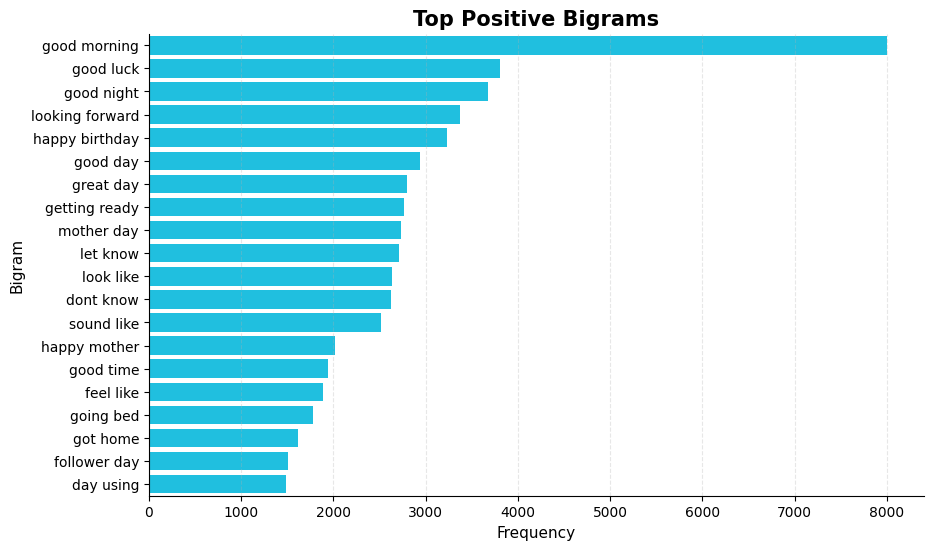

```python
# Plot positive bigrams

plt.figure(figsize=(10,6))

sns.barplot(data=positive_bigrams, x="count",y="ngram",color="#00D4FF")

plt.title("Top Positive Bigrams",fontsize=15,fontweight="bold")

plt.xlabel("Frequency",fontsize=11)

plt.ylabel("Bigram",fontsize=11)

plt.grid(
    axis="x",
    linestyle="--",
    alpha=0.3
)

sns.despine()

plt.show()
```

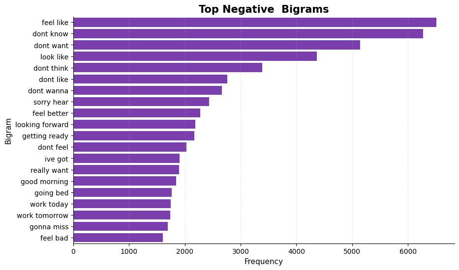

```python
# Plot negative bigrams

plt.figure(figsize=(10,6))

sns.barplot(data=negative_bigrams, x="count",y="ngram",color="#7B2CBF")

plt.title("Top Negative  Bigrams",fontsize=15,fontweight="bold")

plt.xlabel("Frequency",fontsize=11)

plt.ylabel("Bigram",fontsize=11)

plt.grid(
    axis="x",
    linestyle="--",
    alpha=0.3
)

sns.despine()

plt.show()
```

*N-gram analysis helps to identify the common word combinations such as emotional phrases, complaints, and positive expressions.*

```python
# Encode Target Variable

df["target"] = df["sentiment"].map({"Negative": 0,"Positive": 1})

df[["sentiment", "target"]].head()
```

|  | sentiment | target |
| --- | --- | --- |
| 0 | Negative | 0 |
| 1 | Negative | 0 |
| 2 | Negative | 0 |
| 3 | Negative | 0 |
| 4 | Negative | 0 |

# **Data Preprocessing**

```python
# Train Test Split

X = df["clean_text"]
y = df["target"]

X_train, X_test, y_train, y_test = train_test_split(
    X,
    y,
    test_size=0.2,
    random_state=42,
    stratify=y
)

print("X_train:", X_train.shape)
print("X_test:", X_test.shape)
print("y_train:", y_train.shape)
print("y_test:", y_test.shape)
```

```
X_train: (1272397,)
X_test: (318100,)
y_train: (1272397,)
y_test: (318100,)
```

```python
y_train.value_counts(normalize=True) * 100
```

```
target
0    50.023145
1    49.976855
Name: proportion, dtype: float64
```

```python
y_test.value_counts(normalize=True) * 100
```

```
target
0    50.023263
1    49.976737
Name: proportion, dtype: float64
```

```python
# TF-IDF Vectorization

tfidf = TfidfVectorizer(
    max_features=50000,
    ngram_range=(1,2),
    min_df=5,
    max_df=0.90
)

X_train_tfidf = tfidf.fit_transform(X_train)
X_test_tfidf = tfidf.transform(X_test)

print("Training TF-IDF Shape:", X_train_tfidf.shape)
print("Testing TF-IDF Shape:", X_test_tfidf.shape)
```

```
Training TF-IDF Shape: (1272397, 50000)
Testing TF-IDF Shape: (318100, 50000)
```

*TF-IDF converts cleaned text into numerical features. It gives higher importance to meaningful words and lower importance to very common words.*

```python
# Build Multiple Models

models = {
    "Naive Bayes": MultinomialNB(),
    "Logistic Regression": LogisticRegression(max_iter=1000),
    "Linear SVM": LinearSVC()
}
```

```python
model_results = []

for model_name, model in models.items():
    model.fit(X_train_tfidf, y_train)

    y_pred = model.predict(X_test_tfidf)

    accuracy = accuracy_score(y_test, y_pred)
    precision = precision_score(y_test, y_pred)
    recall = recall_score(y_test, y_pred)
    f1 = f1_score(y_test, y_pred)

    model_results.append({
        "Model": model_name,
        "Accuracy": accuracy,
        "Precision": precision,
        "Recall": recall,
        "F1 Score": f1
    })

    print("=" * 60)
    print(model_name)
    print("=" * 60)
    print(classification_report(y_test, y_pred))
```

```
============================================================
Naive Bayes
============================================================
              precision    recall  f1-score   support

           0       0.78      0.78      0.78    159124
           1       0.78      0.78      0.78    158976

    accuracy                           0.78    318100
   macro avg       0.78      0.78      0.78    318100
weighted avg       0.78      0.78      0.78    318100

============================================================
Logistic Regression
============================================================
              precision    recall  f1-score   support

           0       0.81      0.78      0.79    159124
           1       0.78      0.81      0.80    158976

    accuracy                           0.79    318100
   macro avg       0.79      0.79      0.79    318100
weighted avg       0.79      0.79      0.79    318100

============================================================
Linear SVM
============================================================
              precision    recall  f1-score   support

           0       0.80      0.77      0.79    159124
           1       0.78      0.81      0.80    158976

    accuracy                           0.79    318100
   macro avg       0.79      0.79      0.79    318100
weighted avg       0.79      0.79      0.79    318100
```

```python
results_df = pd.DataFrame(model_results)

metric_cols = ["Accuracy", "Precision", "Recall", "F1 Score"]

results_df[metric_cols] = (results_df[metric_cols] * 100).round(2)

for col in metric_cols:
    results_df[col] = results_df[col].astype(str) + "%"

results_df
```

|  | Model | Accuracy | Precision | Recall | F1 Score |
| --- | --- | --- | --- | --- | --- |
| 0 | Naive Bayes | 77.67% | 77.66% | 77.67% | 77.67% |
| 1 | Logistic Regression | 79.43% | 78.37% | 81.27% | 79.79% |
| 2 | Linear SVM | 79.11% | 77.87% | 81.31% | 79.55% |

```python
# Now choose best model

best_model = LogisticRegression(max_iter=1000)
best_model.fit(X_train_tfidf, y_train)

y_pred = best_model.predict(X_test_tfidf)
```

```python
accuracy = accuracy_score(y_test, y_pred)

print(f"Accuracy: {accuracy:.2%}")
```

```
Accuracy: 79.43%
```

```python
# Final Classification Report

print(classification_report(
    y_test,
    y_pred,
    target_names=["Negative", "Positive"]
))
```

```
              precision    recall  f1-score   support

    Negative       0.81      0.78      0.79    159124
    Positive       0.78      0.81      0.80    158976

    accuracy                           0.79    318100
   macro avg       0.79      0.79      0.79    318100
weighted avg       0.79      0.79      0.79    318100
```

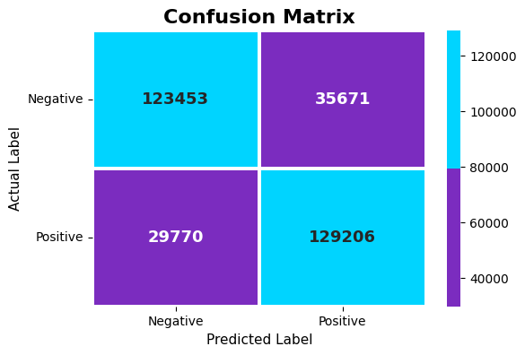

```python
cm = confusion_matrix(y_test, y_pred)

plt.figure(figsize=(6,4))

sns.heatmap(cm,annot=True,fmt="d",cmap=sns.color_palette(["#7B2CBF", "#00D4FF"],as_cmap=True),linewidths=1.5,
    linecolor="white",cbar=True,
    xticklabels=["Negative", "Positive"],
    yticklabels=["Negative", "Positive"],
    annot_kws={"fontsize":13,"fontweight":"bold"}
)

plt.title("Confusion Matrix",fontsize=16,fontweight="bold")

plt.xlabel("Predicted Label",fontsize=11)

plt.ylabel("Actual Label",fontsize=11)

plt.xticks(fontsize=10)
plt.yticks(fontsize=10, rotation=0)

plt.show()
```

*The model correctly identified 123K negativeand 129K positive tweets. It made mistakes on about 65K tweets total. Overall accuracy of approx 79% is strong for real-world noisy Twitter data.*

```python
# Receiver Operating Characteristic (ROC) and Area Under the Curve (AUC) Score

y_pred_proba = best_model.predict_proba(X_test_tfidf)[:, 1]

auc_score = roc_auc_score(y_test, y_pred_proba)

print("ROC-AUC Score:", auc_score)
```

```
ROC-AUC Score: 0.8748588421340131
```

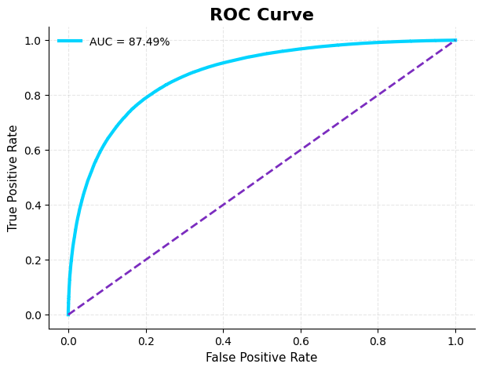

```python
from sklearn.metrics import roc_curve
from matplotlib.colors import LinearSegmentedColormap

fpr, tpr, thresholds = roc_curve(
    y_test,
    y_pred_proba
)

plt.figure(figsize=(7,5))

plt.plot(fpr,tpr,color="#00D4FF",linewidth=3,label=f"AUC = {auc_score:.2%}")

plt.plot([0,1],[0,1],linestyle="--",color="#7B2CBF",linewidth=2)

plt.title("ROC Curve",fontsize=16,fontweight="bold")

plt.xlabel("False Positive Rate",fontsize=11)

plt.ylabel("True Positive Rate",fontsize=11)

plt.legend(frameon=False,fontsize=10)

plt.grid(
    linestyle="--",
    alpha=0.3
)

sns.despine()

plt.show()
```

```python
#  Important Word Analysis (positive/negative)

feature_names = tfidf.get_feature_names_out()
coefficients = best_model.coef_[0]

word_importance = pd.DataFrame({"word": feature_names,"coefficient": coefficients})
top_positive_words = word_importance.sort_values(by="coefficient",ascending=False).head(20)
top_negative_words = word_importance.sort_values(by="coefficient",ascending=True).head(20)
```

```python
top_positive_words
```

|  | word | coefficient |
| --- | --- | --- |
| 5507 | cant wait | 10.634621 |
| 5326 | cannot wait | 8.134812 |
| 47730 | wish luck | 6.284979 |
| 29638 | nothing wrong | 6.101199 |
| 46092 | wasnt bad | 5.729030 |
| 20736 | isnt bad | 5.465664 |
| 37532 | smiling | 5.335960 |
| 25251 | made day | 5.168067 |
| 9608 | doesnt hurt | 5.085491 |
| 40805 | thank | 5.011803 |
| 9897 | dont miss | 4.947888 |
| 14412 | get enough | 4.864094 |
| 9849 | dont forget | 4.833653 |
| 40889 | thanks | 4.822297 |
| 46013 | wanted say | 4.748828 |
| 46965 | welcome | 4.720538 |
| 7066 | congratulation | 4.515210 |
| 15078 | glad | 4.385359 |
| 37521 | smile | 4.380835 |
| 12224 | feel free | 4.349035 |

```python
top_negative_words
```

|  | word | coefficient |
| --- | --- | --- |
| 34876 | sad | -13.169593 |
| 4968 | bummed | -8.257594 |
| 32145 | poor | -8.030077 |
| 26699 | miss | -7.526042 |
| 5331 | cant | -7.429489 |
| 17099 | gutted | -7.371083 |
| 26933 | missing | -7.369232 |
| 35021 | sadly | -7.284313 |
| 36781 | sick | -7.276704 |
| 9431 | disappointing | -7.074343 |
| 9045 | depressed | -6.944550 |
| 34793 | ruined | -6.650646 |
| 9048 | depressing | -6.564137 |
| 44770 | unfair | -6.503613 |
| 47664 | wish | -6.464146 |
| 19889 | hurt | -6.450726 |
| 34551 | rip | -6.388481 |
| 18209 | headache | -6.351814 |
| 44780 | unfortunately | -6.290073 |
| 5301 | cancelled | -6.236347 |

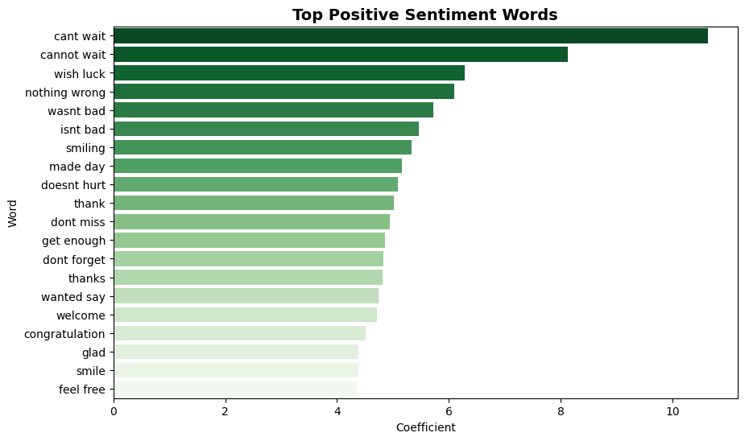

```python
plt.figure(figsize=(10,6))
sns.barplot(data=top_positive_words, x="coefficient", y="word", palette="Greens_r")
plt.title("Top Positive Sentiment Words", fontsize=14, fontweight="bold")
plt.xlabel("Coefficient")
plt.ylabel("Word")
plt.show()
```

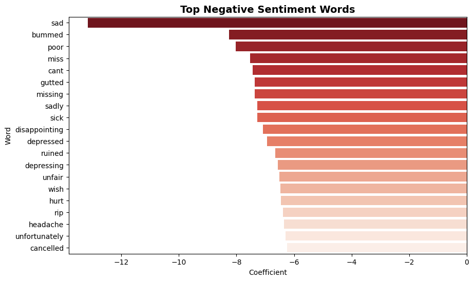

```python
plt.figure(figsize=(10,6))
sns.barplot(data=top_negative_words, x="coefficient", y="word", palette="Reds_r")
plt.title("Top Negative Sentiment Words", fontsize=14, fontweight="bold")
plt.xlabel("Coefficient")
plt.ylabel("Word")
plt.show()
```

```python
# Random Word/sentence Prediction

def predict_sentiment(text):
    cleaned_text = clean_text(text)
    vectorized_text = tfidf.transform([cleaned_text])

    prediction = best_model.predict(vectorized_text)[0]

    if hasattr(best_model, "predict_proba"):
        probability = best_model.predict_proba(vectorized_text)[0]
        confidence = probability[prediction]
    else:
        confidence = None

    if prediction == 1:
        sentiment = "Positive"
    else:
        sentiment = "Negative"

    if confidence is not None:
        return f"Sentiment: {sentiment} | Confidence: {confidence:.2%}"
    else:
        return f"Sentiment: {sentiment}"
```

```python
predict_sentiment("I love this product, it is amazing")
```

```
'Sentiment: Positive | Confidence: 98.49%'
```

```python
predict_sentiment("Very bad things I watch, never seen in my life this things")
```

```
'Sentiment: Negative | Confidence: 59.82%'
```

```python
predict_sentiment("This is the worst experience ever")
```

```
'Sentiment: Negative | Confidence: 85.35%'
```

```python
predict_sentiment("I am so happy with the service. Again I visit in this store future")
```

```
'Sentiment: Positive | Confidence: 88.67%'
```

*The custom prediction system allows users to enter any text and get the predicted sentiment.*

# **Save Clean Dataset**

```python
df.to_csv("cleaned_twitter_nlp_dataset.csv",index=False)
```

# **Save Model**

```python
joblib.dump(best_model, "sentiment_model.pkl")
joblib.dump(tfidf, "tfidf_vectorizer.pkl")
```

```
['tfidf_vectorizer.pkl']
```

# **Final Business Insights**

1. Positive tweets mostly contain words related to happiness, appreciation, excitement, and enjoyment.
2. Negative tweets frequently contain words related to sadness, frustration, disappointment, complaints, and emotional stress.
3. Twitter text is highly noisy because tweets often contain hashtags, mentions, URLs, short forms, and informal language. Because of this, text preprocessing becomes one of the most important steps in NLP.
4. TF-IDF vectorization helped convert raw tweet text into meaningful numerical features by giving higher importance to important sentiment-related words.
5. Among all models, Logistic Regression achieved the best overall performance with around 79% accuracy and strong precision-recall balance.
6. The ROC-AUC score of approximately 0.87 indicates that the model can effectively distinguish between positive and negative sentiment.
7. The final model can be used for real-world applications such as social media monitoring, customer feedback analysis, brand reputation tracking, and public opinion analysis.
8. The custom prediction system can classify completely new tweets into positive or negative sentiment with confidence scores, making the system practical for real-time sentiment analysis tasks.

# **Conclusion**

This project successfully built an end-to-end NLP sentiment analysis system using Twitter text data. The project covered text cleaning, NLP preprocessing, exploratory data analysis, word frequency analysis, WordCloud visualization, n-gram analysis, TF-IDF vectorization, machine learning model building, model evaluation, important word analysis, and custom sentiment prediction.

The final model can predict whether a given text expresses positive or negative sentiment.